# Healt and Economic Consequences of Storms and Other Severe Weather Events

## Synopsis

In this report we aim to describe the healt and economics effects and consequences of storms and other severe weather events in the U.S..

The U.S. National Oceanic and Atmospheric Administration’s (NOAA) storm database tracks characteristics of major storms and weather events in the United States, including when and where they occur, as well as estimates of any fatalities, injuries, and property damage. Events in the database are tracked from 1950 to November 2011.

Exploration of the U.S. NOAA storm database allowed us to identify which severe weather events are to be considered most harmful for the healt of the population and additionally to define which events have the greatest economic impact.

From these data, we found that, **TORNADO** is the type of event which has to be considered the most harmful for the healt of the population, while **FLOOD** is the type of event which has the greatest economic impact.

## Data Processing

### Storm Data

The storm data is available [here](https://d396qusza40orc.cloudfront.net/repdata%2Fdata%2FStormData.csv.bz2), and documentation for the database is available in the [Storm Data Documentation](https://d396qusza40orc.cloudfront.net/repdata%2Fpeer2_doc%2Fpd01016005curr.pdf) and [FAQ](https://d396qusza40orc.cloudfront.net/repdata%2Fpeer2_doc%2FNCDC%20Storm%20Events-FAQ%20Page.pdf).

### Reading the data

Load the compressed data file and read it using the read.csv function:

```r
conn <- bzfile("repdata-data-StormData.csv.bz2", "r")
data <- read.csv(conn)
close(conn)
rm(conn)
str(data)
```

```
## 'data.frame':    902297 obs. of  37 variables:
##  $ STATE__   : num  1 1 1 1 1 1 1 1 1 1 ...
##  $ BGN_DATE  : Factor w/ 16335 levels "1/1/1966 0:00:00",..: 6523 6523 4242 11116 2224 2224 2260 383 3980 3980 ...
##  $ BGN_TIME  : Factor w/ 3608 levels "00:00:00 AM",..: 272 287 2705 1683 2584 3186 242 1683 3186 3186 ...
##  $ TIME_ZONE : Factor w/ 22 levels "ADT","AKS","AST",..: 7 7 7 7 7 7 7 7 7 7 ...
##  $ COUNTY    : num  97 3 57 89 43 77 9 123 125 57 ...
##  $ COUNTYNAME: Factor w/ 29601 levels "","5NM E OF MACKINAC BRIDGE TO PRESQUE ISLE LT MI",..: 13513 1873 4598 10592 4372 10094 1973 23873 24418 4598 ...
##  $ STATE     : Factor w/ 72 levels "AK","AL","AM",..: 2 2 2 2 2 2 2 2 2 2 ...
##  $ EVTYPE    : Factor w/ 985 levels "   HIGH SURF ADVISORY",..: 834 834 834 834 834 834 834 834 834 834 ...
##  $ BGN_RANGE : num  0 0 0 0 0 0 0 0 0 0 ...
##  $ BGN_AZI   : Factor w/ 35 levels "","  N"," NW",..: 1 1 1 1 1 1 1 1 1 1 ...
##  $ BGN_LOCATI: Factor w/ 54429 levels "","- 1 N Albion",..: 1 1 1 1 1 1 1 1 1 1 ...
##  $ END_DATE  : Factor w/ 6663 levels "","1/1/1993 0:00:00",..: 1 1 1 1 1 1 1 1 1 1 ...
##  $ END_TIME  : Factor w/ 3647 levels ""," 0900CST",..: 1 1 1 1 1 1 1 1 1 1 ...
##  $ COUNTY_END: num  0 0 0 0 0 0 0 0 0 0 ...
```

[output cut: 23 more lines]

### Filtering the data

Filter data based on only the **Permitter Storm Data Events** (as reported in the *Storm Data Documentation* §2.1.1):

```r
permitted_events <- c("Astronomical Low Tide", "Avalanche", "Blizzard", "Coastal Flood", "Cold/Wind Chill", "Debris Flow", "Dense Fog", "Dense Smoke", "Drought", "Dust Devil", "Dust Storm", "Excessive Heat", "Extreme Cold/Wind Chill", "Flash Flood", "Flood", "Frost/Freeze", "Funnel Cloud", "Freezing Fog", "Hail", "Heat", "Heavy Rain", "Heavy Snow", "High Surf", "High Wind", "Hurricane (Typhoon)", "Ice Storm", "Lake-Effect Snow", "Lakeshore Flood", "Lightning", "Marine Hail", "Marine High Wind", "Marine Strong Wind", "Marine Thunderstorm Wind", "Rip Current", "Seiche", "Sleet", "Storm Surge/Tide", "Strong Wind", "Thunderstorm Wind", "Tornado", "Tropical Depression", "Tropical Storm", "Tsunami", "Volcanic Ash", "Waterspout", "Wildfire", "Winter Storm", "Winter Weather")

filtered_data <- data[toupper(data$EVTYPE) %in% toupper(permitted_events), ]
head(filtered_data)
```

```
##   STATE__           BGN_DATE BGN_TIME TIME_ZONE COUNTY COUNTYNAME STATE
## 1       1  4/18/1950 0:00:00     0130       CST     97     MOBILE    AL
## 2       1  4/18/1950 0:00:00     0145       CST      3    BALDWIN    AL
## 3       1  2/20/1951 0:00:00     1600       CST     57    FAYETTE    AL
## 4       1   6/8/1951 0:00:00     0900       CST     89    MADISON    AL
## 5       1 11/15/1951 0:00:00     1500       CST     43    CULLMAN    AL
## 6       1 11/15/1951 0:00:00     2000       CST     77 LAUDERDALE    AL
##    EVTYPE BGN_RANGE BGN_AZI BGN_LOCATI END_DATE END_TIME COUNTY_END
## 1 TORNADO         0                                               0
## 2 TORNADO         0                                               0
## 3 TORNADO         0                                               0
## 4 TORNADO         0                                               0
## 5 TORNADO         0                                               0
## 6 TORNADO         0                                               0
##   COUNTYENDN END_RANGE END_AZI END_LOCATI LENGTH WIDTH F MAG FATALITIES
```

[output cut: 20 more lines]

### Analyzing the data

**Fatalities and injuries**

The data was analyzed in order to calculate the total number of fatalities and injuries due to a particular event type. The event types were then sorted in descending order based on the total fatalities occurred. Bar plots are displayed for a subset of all the event types, only the more harmful are showed. It is clear that **TORNADO** is the most harmful event type for the healt of the population.

The code aggregates injuries and fatalities per event type. Then a subset of the 12 event type with the most fatalities is intersected with the 12 event type with the most injuries. This gives the most harmful event types to be displayed in an ordered way in a facet bar plot. The data for the plot is obtained by transforming (melting) the aggregated values.

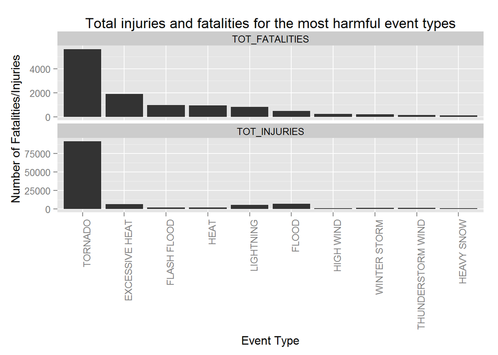

```r
tot_incidents <- aggregate(cbind(INJURIES, FATALITIES) ~ EVTYPE, filtered_data, sum, na.rm = TRUE)
tot_incidents <- setNames(tot_incidents, c("EVTYPE", "TOT_INJURIES", "TOT_FATALITIES"))

top_fatalities <- tot_incidents[with(tot_incidents, order(-TOT_FATALITIES)), ]
top_injuries <- tot_incidents[with(tot_incidents, order(-TOT_INJURIES)), ]

top_incidents <- intersect(top_fatalities[seq(1,12), c("EVTYPE")], top_injuries[seq(1,12), c("EVTYPE")])

library(reshape2)
tot_incidents <- melt(tot_incidents, id.vars=c("EVTYPE"))
tot_incidents <- subset(tot_incidents, EVTYPE %in% top_incidents)
tot_incidents$variable <- relevel(tot_incidents$variable, "TOT_FATALITIES")
tot_incidents <- tot_incidents[with(tot_incidents, order(variable, -value)), ]

library(ggplot2)
library(plyr)
ggplot(tot_incidents, aes(x=EVTYPE, y=value)) + geom_bar(stat="identity") + facet_wrap( ~ variable, ncol=1, scales = "free_y") + theme(axis.text.x = element_text(angle = 90, hjust = 1)) + scale_x_discrete(limits=unique(tot_incidents$EVTYPE)) + xlab("Event Type") + ylab("Number of Fatalities/Injuries") + ggtitle("Total injuries and fatalities for the most harmful event types")
```

**Economical Damages**

The data was further analyzed in order to identify the event with greatest economical impact. The analysis clearly shows that **FLOOD** is the event type with the greatest economical impact.

The code calculate the economical damage for each event type by multiplying CROP and PROP damages with their factors (hundreds “h/H”, tousands “k/K”, millions “m/M”, billions “b/B”) and then adds them together. The economic damage is then aggregated per event type, giving the total economic damage which is then displayed in an ordered way for the 10 most damaging event types.

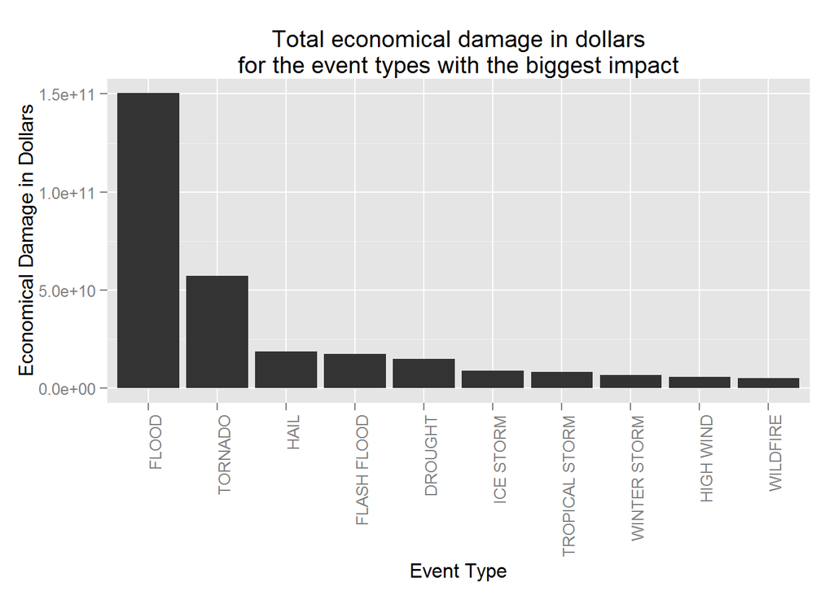

```r
filtered_data$PROPDMGEXP <- gsub("B", 1000000000, ignore.case = TRUE, gsub("M", 1000000, ignore.case = TRUE, gsub("K", 1000, ignore.case = TRUE, gsub("H", 100, ignore.case = TRUE,gsub("$^", 1, filtered_data$PROPDMGEXP)))))

filtered_data$CROPDMGEXP  <- gsub("B", 1000000000, ignore.case = TRUE, gsub("M", 1000000, ignore.case = TRUE, gsub("K", 1000, ignore.case = TRUE, gsub("H", 100, ignore.case = TRUE, gsub("$^", 1, filtered_data$CROPDMGEXP)))))

filtered_data$economical_damage <- suppressWarnings(filtered_data$CROPDMG * as.numeric(filtered_data$CROPDMGEXP) + filtered_data$PROPDMG * as.numeric(filtered_data$PROPDMGEXP))

tot_ecodmg <- aggregate(economical_damage ~ EVTYPE, filtered_data, sum, na.rm = TRUE)
tot_ecodmg <- tot_ecodmg[with(tot_ecodmg, order(-economical_damage)), ]

ggplot(head(tot_ecodmg, n = 10), aes(x=EVTYPE, y=economical_damage)) + geom_bar(stat="identity") + theme(axis.text.x = element_text(angle = 90, hjust = 1)) + scale_x_discrete(limits=head(tot_ecodmg$EVTYPE,10)) + xlab("Event Type") + ylab("Economical Damage in Dollars") + ggtitle("Total economical damage in dollars\nfor the event types with the biggest impact")
```

## Results

This research clearly shows that:

1. **TORNADO** is the most harmful event type for the population.
2. **FLOOD** is the event type with the biggest economic impact.